# Modern Data Mining, HW 1

Spencer Mateega

Mehul Suri

Aditya Maddipatla

Due: 11:59PM, Jan. 29th, 2023

# 1 Overview

This is a fast-paced course that covers a lot of material. There will be a large amount of references. You may need to do your own research to fill in the gaps in between lectures and homework/projects. It is impossible to learn data science without getting your hands dirty. Please budget your time evenly. Last-minute work ethic will not work for this course.

Homework in this course is different from your usual homework assignment as a typical student. Most of the time, they are built over real case studies. While you will be applying methods covered in lectures, you will also find that extra teaching materials appear here. The focus will be always on the goals of the study, the usefulness of the data gathered, and the limitations in any conclusions you may draw. Always try to challenge your data analysis in a critical way. Frequently, there are no unique solutions.

Case studies in each homework can be listed as your data science projects (e.g. on your CV) where you see fit.

## 1.1 Objectives

- Get familiar with `R-studio` and `RMarkdown`
- Hands-on R
- Learn data science essentials
  - gather data
  - clean data
  - summarize data
  - display data
  - conclusion
- Packages
  - `dplyr`
  - `ggplot`

## 1.2 Instructions

- **Homework assignments can be done in a group consisting of up to three members**. Please find your group members as soon as possible and register your group on our Canvas site.
- **All work submitted should be completed in the R Markdown format.** You can find a cheat sheet for R Markdown [here](https://www.rstudio.com/wp-content/uploads/2015/02/rmarkdown-cheatsheet.pdf) For those who have never used it before, we urge you to start this homework as soon as possible.
- **Submit the following files, one submission for each group:** (1) Rmd file, (2) a compiled HTML or pdf version, and (3) all necessary data files if different from our source data. You may directly edit this .rmd file to add your answers. If you intend to work on the problems separately within your group, compile your answers into one Rmd file before submitting. We encourage that you at least attempt each problem by yourself before working with your teammates. Additionally, ensure that you can ‘knit’ or compile your Rmd file. It is also likely that you need to configure Rstudio to properly convert files to PDF. [**These instructions**](http://kbroman.org/knitr_knutshell/pages/latex.html#converting-knitrlatex-to-pdf) might be helpful.
- In general, be as concise as possible while giving a fully complete answer to each question. All necessary datasets are available in this homework folder on Canvas. Make sure to document your code with comments (written on separate lines in a code chunk using a hashtag `#` before the comment) so the teaching fellows can follow along. R Markdown is particularly useful because it follows a ‘stream of consciousness’ approach: as you write code in a code chunk, make sure to explain what you are doing outside of the chunk.
- A few good or solicited submissions will be used as sample solutions. When those are released, make sure to compare your answers and understand the solutions.

## 1.3 Review materials

- Study Basic R Tutorial
- Study Advanced R Tutorial (to include `dplyr` and `ggplot`)
- Study lecture 1: Data Acquisition and EDA

# 2 Case study 1: Audience Size

How successful is the Wharton Talk Show [Business Radio Powered by the Wharton School](https://businessradio.wharton.upenn.edu/)

**Background:** Have you ever listened to [SiriusXM](https://www.siriusxm.com/)? Do you know there is a **Talk Show** run by Wharton professors in Sirius Radio? Wharton launched a talk show called [Business Radio Powered by the Wharton School](https://businessradio.wharton.upenn.edu/) through the Sirius Radio station in January of 2014. Within a short period of time the general reaction seemed to be overwhelmingly positive. To find out the audience size for the show, we designed a survey and collected a data set via MTURK in May of 2014. Our goal was to **estimate the audience size**. There were 51.6 million Sirius Radio listeners then. One approach is to estimate the proportion of the Wharton listeners to that of the Sirius listeners, $p$, so that we will come up with an audience size estimate of approximately 51.6 million times $p$.

To do so, we launched a survey via Amazon Mechanical Turk ([MTurk](https://www.mturk.com/)) on May 24, 2014 at an offered price of $0.10 for each answered survey. We set it to be run for 6 days with a target maximum sample size of 2000 as our goal. Most of the observations came in within the first two days. The main questions of interest are “Have you ever listened to Sirius Radio” and “Have you ever listened to Sirius Business Radio by Wharton?”. A few demographic features used as control variables were also collected; these include Gender, Age and Household Income.

We requested that only people in United States answer the questions. Each person can only fill in the questionnaire once to avoid duplicates. Aside from these restrictions, we opened the survey to everyone in MTurk with a hope that the sample would be more randomly chosen.

The raw data is stored as `Survey_results_final.csv` on Canvas.

## 2.1 Data preparation

1. We need to clean and select only the variables of interest.

Select only the variables Age, Gender, Education Level, Household Income in 2013, Sirius Listener?, Wharton Listener? and Time used to finish the survey.

Change the variable names to be “age”, “gender”, “education”, “income”, “sirius”, “wharton”, “worktime”.

```r
# get data
data <- read.csv("data/Survey_results_final.csv", header=T, stringsAsFactors = FALSE)
# select needed variables
data_cleaned <- data %>% select(Answer.Age, Answer.Gender, Answer.Education, Answer.HouseHoldIncome, Answer.Sirius.Radio, Answer.Wharton.Radio, WorkTimeInSeconds)

# rename variables
data_cleaned <- data_cleaned %>% rename(age = Answer.Age, gender = Answer.Gender, education = Answer.Education, income = Answer.HouseHoldIncome, sirius = Answer.Sirius.Radio, wharton = Answer.Wharton.Radio, worktime = WorkTimeInSeconds)

data_cleaned[1:5,]
```

2. Handle missing/wrongly filled values of the selected variables

As in real world data with user input, the data is incomplete, with missing values, and has incorrect responses. There is no general rule for dealing with these problems beyond “use common sense.” In whatever case, explain what the problems were and how you addressed them. Be sure to explain your rationale for your chosen methods of handling issues with the data. Do not use Excel for this, however tempting it might be.

Tip: Reflect on the reasons for which data could be wrong or missing. How would you address each case? For this homework, if you are trying to predict missing values with regression, you are definitely overthinking. Keep it simple.

```r
# AGE

# one person put "female" for their age
# -> delete this entry because we don't want to guess a wrong age
data_cleaned$age[data_cleaned$age == 'female'] <- ""

# one person put "Eighteen (18)" as age
# -> change age to 18
data_cleaned$age[data_cleaned$age == 'Eighteen (18)'] <- '18'

# one person put "27`" as age
# -> change age to 27
data_cleaned$age[data_cleaned$age == '27`'] <- "27"

# some entries missing age, gender, income, sirius, and/or wharton
# -> remove entries from dataset because we don't want to guess the value
data_cleaned <- data_cleaned[!(data_cleaned$age=="" | data_cleaned$gender=="" | data_cleaned$income==""| data_cleaned$sirius=="" | data_cleaned$wharton=="" ), ]

# change age to numeric format
data_cleaned$age <- as.numeric(data_cleaned$age)

# one entry has age as 223 and another has age as 4
# -> these are fake ages so remove the entries
data_cleaned <- data_cleaned[!(data_cleaned$age==223 | data_cleaned$age==4) ,]

# 17 people had "select one" as education
# -> remove these as we don't want to guess the value
data_cleaned <- data_cleaned[!(data_cleaned$education=="select one"),]
```

3. Brief summary

Write a brief report to summarize all the variables collected. Include both summary statistics (including sample size) and graphical displays such as histograms or bar charts where appropriate. Comment on what you have found from this sample. (For example - it’s very interesting to think about why would one work for a job that pays only 10cents/each survey? Who are those survey workers? The answer may be interesting even if it may not directly relate to our goal.)

After cleaning the data, there were 1727 observations.

We collected data on age, gender, education, income, whether or not they listened to the sirius station, whether or not they listened to the wharton station, and time it took to complete.

Age:

- median: 28, mean: 30.3

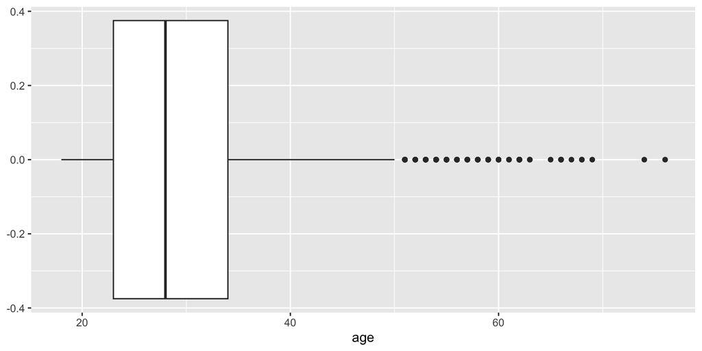

```r
summary(data_cleaned$age)
age <- ggplot(data_cleaned, aes(age))
age + geom_boxplot()
```

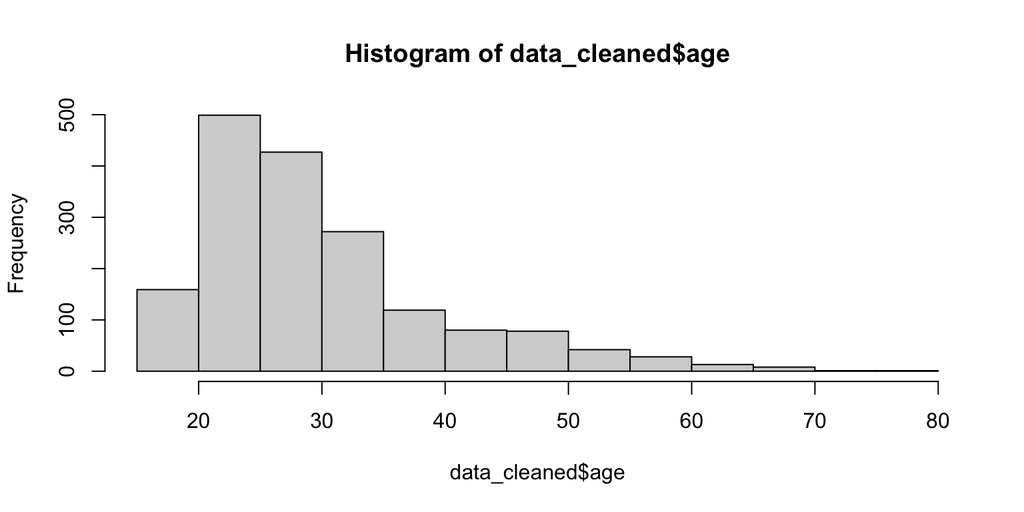

```r
data_cleaned$age = as.numeric(as.character(data_cleaned$age))
summary(data_cleaned)
hist(data_cleaned$age, breaks = 20)
```

Gender:

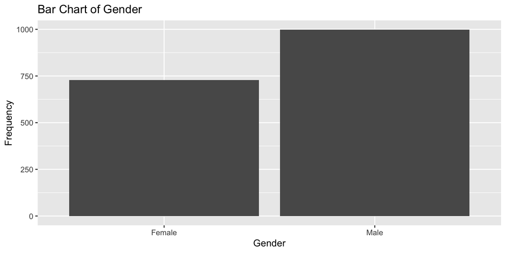

```r
sum(data_cleaned$gender =="Female") /  nrow(data_cleaned) # 42.2%
sum(data_cleaned$gender =="Male") /  nrow(data_cleaned) # 57.8%

p4 <- ggplot(data_cleaned) +
  geom_bar(aes(x = gender)) +
  labs( title = "Bar Chart of Gender", x = "Gender" , y = "Frequency")
p4
```

Education

- most respondents fell under “Bachelor’s degree or other 4-year degree” or “Some college, no diploma; or Associate’s degree” (78.1% of respondents)

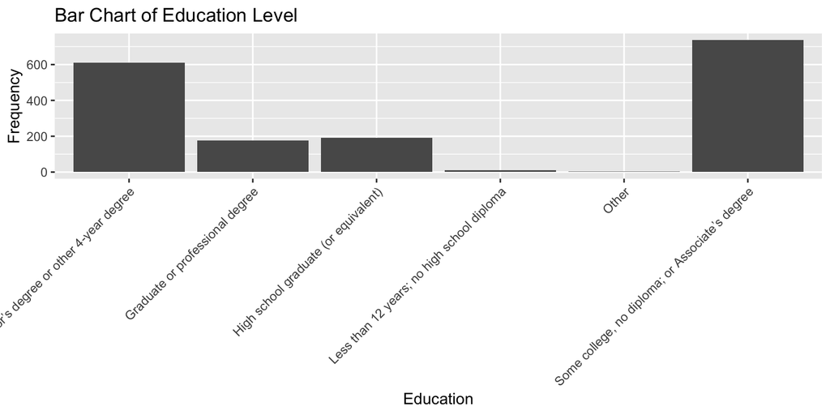

```r
p3 <- ggplot(data_cleaned) +
  geom_bar(aes(x = education)) +
  theme(axis.text.x = element_text(angle = 45, hjust = 1)) +
  labs( title = "Bar Chart of Education Level", x = "Education" , y = "Frequency")
p3
```

Income

- income was fairly distributed across the avaliable options to choose from, with 97% of respondents with income less than $150,000
- because completing this survey only pays 10 cents, our dataset is ignoring people on the higher end of the income spectrum who value their time more than the amount this survey pays
- given there is a general positive correlation between income and education level, our dataset most likely also skews towards people with less education

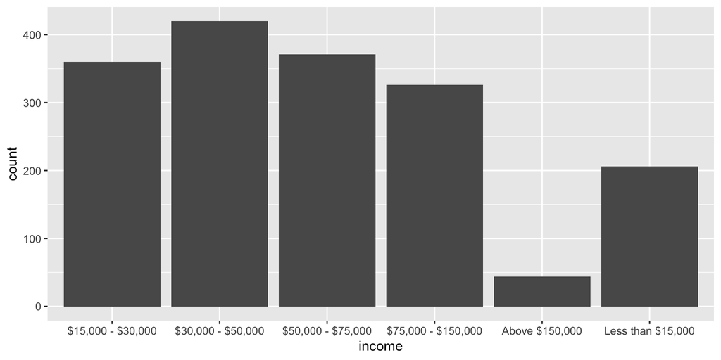

```r
sum(data_cleaned$income =="Above $150,000") / nrow(data_cleaned) # 2.6%
income <- ggplot(data_cleaned, aes(income))
income + geom_bar()
```

Sirius, Wharton and worktime

- 77.4% of respondents listen to SiriusXM while only 4% of respondents listen to the Wharton show
- it took an average of 22.5 seconds (median of 21) to complete this survey. this isn’t too quick for me to question the data

```r
sum(data_cleaned$sirius =="Yes") / nrow(data_cleaned) # 77.4%
sum(data_cleaned$wharton =="Yes") / nrow(data_cleaned)  # 4%

mean(data_cleaned$worktime)
median(data_cleaned$worktime)
```

## 2.2 Sample properties

The population from which the sample is drawn determines where the results of our analysis can be applied or generalized. We include some basic demographic information for the purpose of identifying sample bias, if any exists. Combine our data and the general population distribution in age, gender and income to try to characterize our sample on hand.

1. Does this sample appear to be a random sample from the general population of the USA?

AGE:

- the median age in the US is 38 vs our median age of 28

US population (via wikipedia) vs our population:

0 – 14 years: 18.2% vs 0% 15 – 24 years: 13.0% vs 32.3% 25 – 54 years: 39.0% vs 64.3% 55 – 64 years: 12.9% vs 2.9% 65 years and over: 16.8% vs 0.6%

Source: https://en.wikipedia.org/wiki/Demographics_of_the_United_States

Age:

Hence our data has more centered around poeple 15-64, where as the US population is more evenly distributed across all age groups. Our dataset has nearly no representation of people less than 15 or over 65

```r
n <- nrow(data_cleaned)
summary(data_cleaned$age) # median: 28, mean: 30.3

n014 <- sum(data_cleaned$age <= 14)
n15up <- sum(data_cleaned$age >= 15)
n25up <- sum(data_cleaned$age >= 25)
n55up <- sum(data_cleaned$age >= 55)
n65up <- sum(data_cleaned$age >= 65)

n1524 <- n15up - n25up
n2554 <- n25up - n55up
n5564 <- n55up - n65up

n014 / n # 0%
n1524 / n # 32.3%
n2554 / n # 64.3%
n5564 / n # 2.9%
n65up / n # 0.6%
```

Gender:

- the US population is 50.5% Female and 49.5% Male vs our sample’s population is 42.2% Female and 57.8% Male. So our sample’s population skews more male than the US population (not by a huge margin though)

```r
n <- nrow(data_cleaned)
f <- sum(data_cleaned$gender=="Female")
m <- sum(data_cleaned$gender=="Male")
f / n # 42.2%
m / n # 57.8%
```

Income:

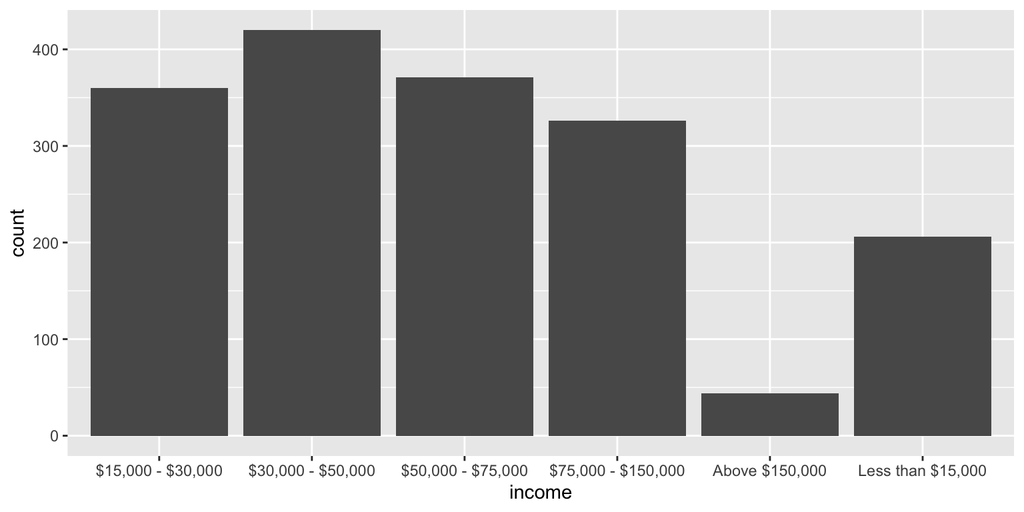

```r
income <- ggplot(data_cleaned, aes(income))
income + geom_bar()
```

```r
sum(data_cleaned$income=="Less than $15,000") / n # 0.119
sum(data_cleaned$income=="$15,000 - $30,000") / n # 0.208
sum(data_cleaned$income=="$30,000 - $50,000") / n # 0.243
sum(data_cleaned$income=="$50,000 - $75,000") / n # 0.215
sum(data_cleaned$income=="$75,000 - $150,000") / n # 0.189
sum(data_cleaned$income=="Above $150,000") / n # 0.0255
```

2. Does this sample appear to be a random sample from the MTURK population?

Note: You can not provide evidence by simply looking at our data here. For example, you need to find distribution of education in our age group in US to see if the two groups match in distribution. You may need to gather some background information about the MTURK population to have a slight sense if this particular sample seem to a random sample from there… Please do not spend too much time gathering evidence.

Source of MTURK Population: https://www.cloudresearch.com/resources/blog/who-uses-amazon-mturk-2020-demographics/

Age:

- Age in our dataset and MTURK have similar distributions, with a peak in the 20s/30s. Both populations are skewed to the right

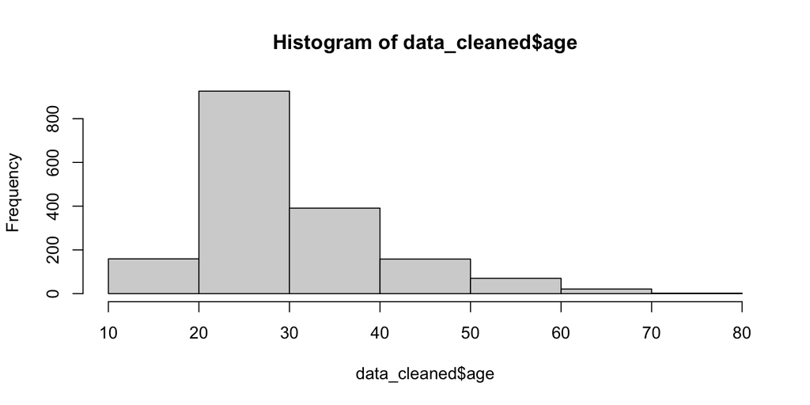

```r
data_cleaned$age = as.numeric(as.character(data_cleaned$age))
summary(data_cleaned)
hist(data_cleaned$age, breaks = 5)
```

Gender:

- MTURK skews slightly female (57% female) vs our dataset is skews slightly male (58% male). This difference could be due to a small sample size.

Education:

- In our dataset, most respondents fell under “Bachelor’s degree or other 4-year degree” or “Some college, no diploma; or Associate’s degree” (78.1% of respondents)
- In the MTURK dataset, 51% of respondents full under “College degree or more” and 36% fell under “Some college”
- So, both populations had similar education levels

Income:

- Income levels are similar between our population and the MTURK population. The highest proportion of MTURK respondents had a salary between 20,000 USD and 60,000 USD. This is similar to our population, which had the largest number of respondents with salary between 30,000 USD and 50,000 USD.

Conclusion:

- Our dataset’s population generally has similar characteristics to the MTURK population. The only main difference is that our population skews male while the MTURK population skews female.

## 2.3 Final estimate

Give a final estimate of the Wharton audience size in January 2014. Assume that the sample is a random sample of the MTURK population, and that the proportion of Wharton listeners vs. Sirius listeners in the general population is the same as that in the MTURK population. Write a brief executive summary to summarize your findings and how you came to that conclusion.

## 2.4 New task

Now suppose you are asked to design a study to estimate the audience size of Wharton Business Radio Show as of today: You are given a budget of $1000. You need to present your findings in two months.

Write a proposal for this study which includes:

1. Method proposed to estimate the audience size.
2. What data should be collected and where it should be sourced from. Please fill in the google form to list your platform where surveys will be launched and collected [HERE](https://forms.gle/8SmjFQ1tpqr6c4sa8)

A good proposal will give an accurate estimation with the least amount of money used.

We can launch a survey to first estimate the number of Sirius Radio, with a question asking “Have you listened to Sirius XM?”. If they have listened to Sirius XM, we can then provide a short list of the shows of various popularities of Sirius Radio including the Wharton Business Radio Show and ask which shows the user has listened too, recording their response in the form of chekcboxes on the list of shows. In addition, we will have a few more questions regarding demographic details (age, gender, income level, and education level). We can use this to estimate the proportion, p, of survey respondents who listened to the Wharton Business Radio Show and multiply it by US population (331.9 million).

For example, if 3% of survey respondents say they listen to Wharton Business Radio Show then we’d estimate that there are 3% * 331.9 million = 9.96 million Wharton Business Radio Show listeners.

The platform we will use to survey our audience is SurveyMonkey Audience – a platform that allows you to create a survey then send it out to your desired target audience. SurveyMonkey handles the respondent sourcing, which leads to us, the surveyor, paying a fee. Using SurveyMonkey’s “General Population”, we will survey a sample from the US, all genders, all ages, and all income levels. For $975, we will get 650 survey responses. SurveyMonkey projects us to receive our responses within 24 hours, which is significantly quicker than the 2 month time restriction.

# 3 Case study 2: Women in Science

Are women underrepresented in science in general? How does gender relate to the type of educational degree pursued? Does the number of higher degrees increase over the years? In an attempt to answer these questions, we assembled a data set (`WomenData_06_16.xlsx`) from [NSF](https://ncses.nsf.gov/pubs/nsf19304/digest/field-of-degree-women) about various degrees granted in the U.S. from 2006 to 2016. It contains the following variables: Field (Non-science-engineering (`Non-S&E`) and sciences (`Computer sciences`, `Mathematics and statistics`, etc.)), Degree (`BS`, `MS`, `PhD`), Sex (`M`, `F`), Number of degrees granted, and Year.

Our goal is to answer the above questions only through EDA (Exploratory Data Analyses) without formal testing. We have provided sample R-codes in the appendix to help you if needed.

## 3.1 Data preparation

1. Understand and clean the data

Notice the data came in as an Excel file. We need to use the package `readxl` and the function `read_excel()` to read the data `WomenData_06_16.xlsx` into R.

a). Read the data into R.

```r
genderData <- read_excel("data/WomenData_06_16.xlsx")
genderData
```

b). Clean the names of each variables. (Change variable names to `Field`,`Degree`, `Sex`, `Year` and `Number` )

```r
genderData <- genderData %>%
  rename(Field = `Field and sex`, Number = `Degrees Awarded`)
```

c). Set the variable natures properly.

```r
genderData$Number = as.numeric(as.character(genderData$Number))
```

d). Any missing values?

No missing values

```r
summary(genderData)
```

2. Write a summary describing the data set provided here.

a). How many fields are there in this data?

b). What are the degree types?

BS, MS, and PhD.

c). How many year’s statistics are being reported here?

2006-2016 is being reported, so 11 years.

## 3.2 BS degrees in 2015

Is there evidence that more males are in science-related fields vs `Non-S&E`? Provide summary statistics and a plot which shows the number of people by gender and by field. Write a brief summary to describe your findings.

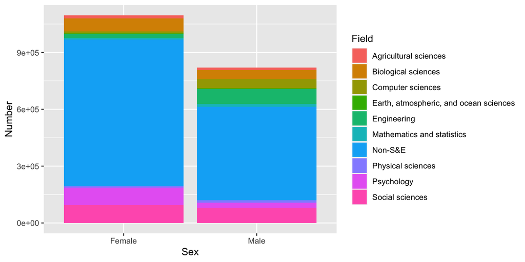

```r
genderData %>%
  filter(Year==2015 & Degree =='BS') %>%
  ggplot(aes(x = Sex, y = Number, fill = Field)) +
  geom_bar(position = "stack", stat = "identity")
```

```r
genderData %>%
  filter(Year==2015 & Degree =='BS') %>%
  group_by(Sex) %>%
  summarize(total_people = sum(Number))
```

Yes, there seems to be a much larger proportion of Females that are in Non-S&E than Males in Non-S&E based on the plot. There are 772,768 Females in Non-S&E fields in 2015 who have a Bachelor’s degree from the total of 1,095,703 Females. For Males, there are 493,304 in Non-S&E out of the total of 820,426 Males.

## 3.3 EDA bringing type of degree, field and gender in 2015

Describe the number of people by type of degree, field, and gender. Do you see any evidence of gender effects over different types of degrees? Again, provide graphs to summarize your findings.

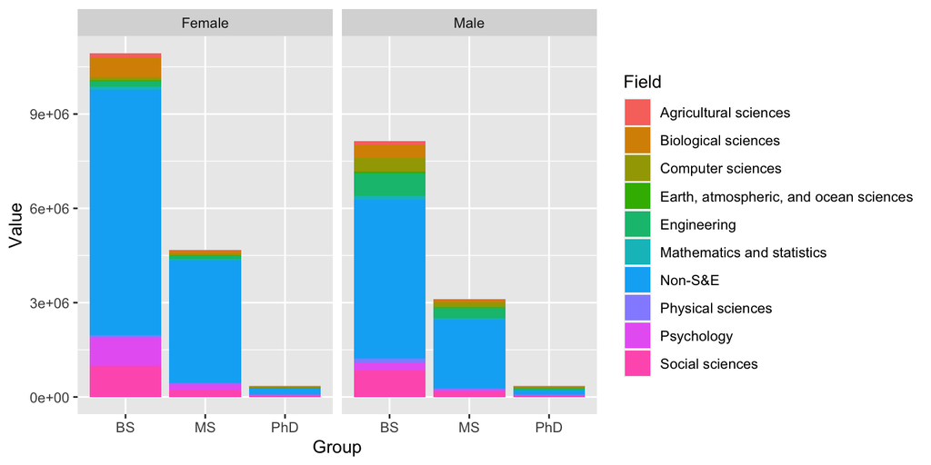

```r
ggplot(genderData, aes(x = Degree, y = Number, fill = Field)) +
  geom_bar(position = "stack", stat = "identity") +
  xlab("Group") +
  ylab("Value") +
  facet_wrap(~ Sex)
```

Based on the graph, it seems that the largest disparity is among Masters students where a higher proportion of females are in non Science-related fields compared to Men with Masters Degrees. This disparity is less pronounced among BS individuals however there still seems to be a slightly higher proportion of females in non Science-related fields compared to Men. For PhD, the distributions seems to be quite similar. The exact numbers by type of degree, field, and gender are as following:

```r
genderData %>%
  filter(Year==2015) %>%
  group_by(Degree, Field, Sex) %>%
  summarize(total_people = sum(Number))
```

## 3.4 EDA bring all variables

In this last portion of the EDA, we ask you to provide evidence numerically and graphically: Do the number of degrees change by gender, field, and time?

```r
fieldsOverTime <- genderData %>%
  group_by(Year, Field, Sex) %>%
  summarize(total_people = sum(Number)) %>%
  arrange(Field, Year)
fieldsOverTime
```

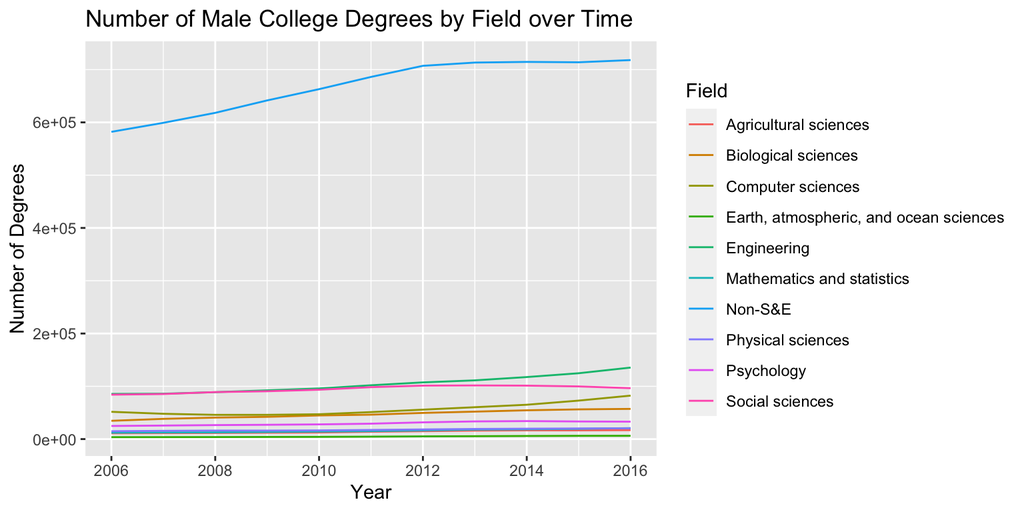

```r
MaleOverTime <- fieldsOverTime %>%
  filter(Sex == 'Male')
ggplot(MaleOverTime, aes(x = Year, y = total_people)) +
  geom_line(aes(color = Field)) +
  xlab("Year") +
  ylab("Number of Degrees") +
  ggtitle("Number of Male College Degrees by Field over Time")
```

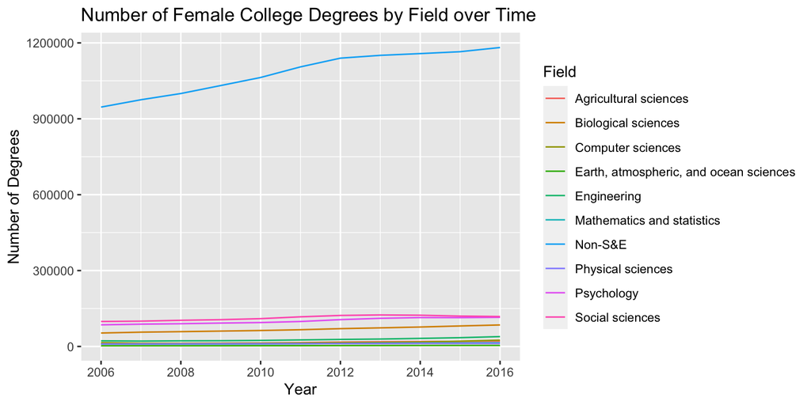

```r
FemaleOverTime <- fieldsOverTime %>%
  filter(Sex == 'Female')
ggplot(FemaleOverTime, aes(x = Year, y = total_people)) +
  geom_line(aes(color = Field)) +
  xlab("Year") +
  ylab("Number of Degrees") +
  ggtitle("Number of Female College Degrees by Field over Time")
```

Based on the plots and the table we can see that over time the number of Non-S&E degrees has been growing for both Males and Females but more sharply for Females. In addition, in recent years it seems as though the number of Science-related degrees for Females has plateaud while Male science related degrees are growing. The data table above displays the numerical values that illustrate this point.

## 3.5 Women in Data Science

Finally, is there evidence showing that women are underrepresented in data science? Data science is an interdisciplinary field of computer science, math, and statistics. You may include year and/or degree.

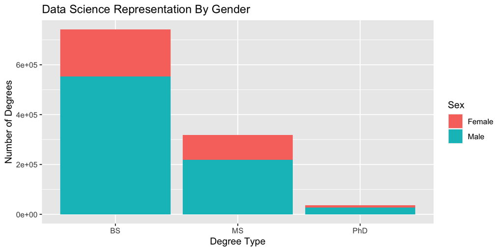

```r
dataScienceData <- genderData %>%
  filter(Field == "Computer sciences" | Field == "Mathematics and statistics") %>%
  group_by(Sex, Degree) %>%
  summarize(total_people = sum(Number))
dataScienceData %>%
  ggplot(aes(x = Degree, y = total_people, fill = Sex)) +
  geom_bar(position = "stack", stat = "identity") +
  xlab("Degree Type") +
  ylab("Number of Degrees") +
  ggtitle("Data Science Representation By Gender")
```

Based on the above graph, we see that in the majors most related to data science there is an overrepresentation of males in these majors across all degrees. Based on this, we may conclude that there is an underrepresentation of females in the data science major.

## 3.6 Final brief report

Summarize your findings focusing on answering the questions regarding if we see consistent patterns that more males pursue science-related fields. Any concerns with the data set? How could we improve on the study?

Based on our findings, it seems that females are underrepresented in science-related fields and a smaller proportion of females are in those fields compared to men. Our stacked bar chart earlier on from 2015 displayed this insight as Non-S&E made up a much larger portion for female graduates than it did for men. Moreover, analyzing the evolution of the number of degrees in different fields for Males and Females over time showed that the number of males in Science related degrees is growing more consistently than it is for Females. Some concerns for the data set include that it only includes data from the US. An analysis of this same question for a worldwide data set may yield different results. Moreover, the data only goes up to 2016 so more recent years might show us different insights. This study could also be improved by looking at the job positions of these degree holders. We may find a disparity between Males and Females with regards to where they fall within the corporate ladder.

# 4 Case study 3: Major League Baseball

We would like to explore how payroll affects performance among Major League Baseball teams. The data is prepared in two formats record payroll, winning numbers/percentage by team from 1998 to 2014.

Here are the datasets:

-`MLPayData_Total.csv`: wide format -`baseball.csv`: long format

Feel free to use either dataset to address the problems.

```r
mldata1 <- read.csv("data/MLPayData_Total.csv", header=T, stringsAsFactors = FALSE)
mldata2 <- read.csv("data/baseball.csv", header=T, stringsAsFactors = FALSE)
```

## 4.1 EDA: Relationship between payroll changes and performance

Payroll may relate to performance among ML Baseball teams. One possible argument is that what affects this year’s performance is not this year’s payroll, but the amount that payroll increased from last year. Let us look into this through EDA.

Create increment in payroll

a). To describe the increment of payroll in each year there are several possible approaches. Take 2013 as an example:

```
- option 1: diff: payroll_2013 - payroll_2012
- option 2: log diff: log(payroll_2013) - log(payroll_2012)
```

Explain why the log difference is more appropriate in this setup.

If we convert data to its log space, we turn relative changes into absolute changes. Since we are dealing with relative (“incremental”) changes we want to log our data. This means we can better compare data that have different absolute values. Hence an increase in pay from 100,000 USD to 110,000 USD and an increase in pay from 1,000,000 USD to 1,100,000 USD will appear the same, which is what we want.

b). Create a new variable `diff_log=log(payroll_2013) - log(payroll_2012)`. Hint: use `dplyr::lag()` function.

c). Create a long data table including: team, year, diff_log, win_pct

```r
mldata3 <- mldata2
mldata3 = select(mldata3, -win_num)
mldata3$diff_log <- log(mldata3$payroll) - log(lag(mldata3$payroll))
mldata3$diff_log[mldata3$year==1998] <- NA
mldata3 = select(mldata3, -payroll)
```

## 4.2 Exploratory questions

a). Which five teams had highest increase in their payroll between years 2010 and 2014, inclusive?

```r
teams <- mldata3[!duplicated(mldata3$team),1] # each team

mldataHighestPay <- data.frame(matrix(ncol = 2, nrow = 0)) # create a new table
colnames(mldataHighestPay) <- c('team', 'pay') # add team and pay
mldataHighestPay$team <- as.character(mldataHighestPay$team)
mldataHighestPay$pay <- as.numeric(mldataHighestPay$pay)

for (i in 1:length(teams)) {
  mldataHighestPay <- mldataHighestPay%>%
    add_row(
      team = teams[i],
      pay = with(mldata3,sum(diff_log[(year>=2010 & year<=2014) & (team==teams[i])])) #sum the pay increase in years 2010-2014
    )
}
top5teams <- mldataHighestPay[order(mldataHighestPay$pay,decreasing=TRUE),]
top5teams[1:5,]
```

The teams with the greatest pay increase (via log difference) were 1) Los Angeles Dodgers, 2) Washington Nationals, 3) San Diego Padres, 4) Texas Rangers, and 5) San Francisco Giants

b). Between 2010 and 2014, inclusive, which team(s) “improved” the most? That is, had the biggest percentage gain in wins?

```r
teams <- mldata3[!duplicated(mldata3$team),1] # each team

mldataMostImproved <- data.frame(matrix(ncol = 2, nrow = 0)) # create a new table
colnames(mldataMostImproved) <- c('team', 'win_improv') # add team and pay
mldataMostImproved$team <- as.character(mldataMostImproved$team)
mldataMostImproved$win_improv <- as.numeric(mldataMostImproved$win_improv)

for (i in 1:length(teams)) {
  mldataMostImproved <- mldataMostImproved %>%
    add_row(
      team = teams[i],
      win_improv = with(mldata3,sum(win_pct[(year==2014) & (team==teams[i])])) - with(mldata3,sum(win_pct[(year==2010) & (team==teams[i])])) #sum the pay increase in years 2010-2014
    )
}
top5teams <- mldataMostImproved[order(mldataMostImproved$win_improv,decreasing=TRUE),]
top5teams[1:5,]
```

The teams that improved the most (had the biggest difference in percentage of wins) from 2010 to 2014 were 1) Pittsburgh Pirates, 2) Baltimore Orioles, 3) Washington Nationals, 4) Seattle Mariners, and 5) Kansas City Royals

## 4.3 Do log increases in payroll imply better performance?

Is there evidence to support the hypothesis that higher increases in payroll on the log scale lead to increased performance?

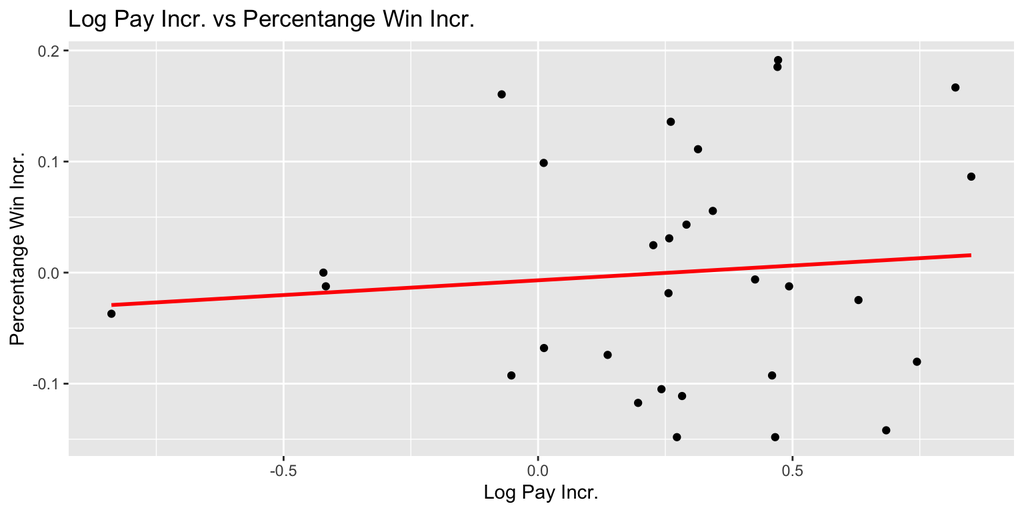

```r
mldataHighestPay$win_improv = mldataMostImproved$win_improv
g <- ggplot(mldataHighestPay, aes(pay, win_improv))
g + geom_point() + labs(title="Log Pay Incr. vs Percentange Win Incr.", x="Log Pay Incr.", y="Percentange Win Incr.") + geom_smooth(method = "lm", formula = y ~ x, se = F,color = "red")
```

```r
cor(mldataHighestPay$win_improv, mldataHighestPay$pay)
```

Pick up a few statistics, accompanied with some data visualization, to support your answer.

There isn’t evidence that supports that a payroll increase (on the log scale) leads to a significant increased performance. Plotting Log Pay Incr. vs Percentange Win Incr. we see that the data points are very scattered and don’t follow an apparent trend. Looking at a line of best fit we see that there is a slight increase in slope, but with huge variance.

The correlation between Log Pay Incr. and Percentange Win Incr. is 0.0939, which is very low.

Only one team (Washington Nationals) is in the list of both highest increase in payroll and highest increase in performance, which also implies minimal correlation.

## 4.4 Comparison

Which set of factors are better explaining performance? Yearly payroll or yearly increase in payroll? What criterion is being used?

Yearly payroll is better as explaining performance. If we chart payroll vs win_pct and control for year, we see a clear positive relationship between payroll and win_pct, meaning the more a team is paid, the better we expect them to perform.

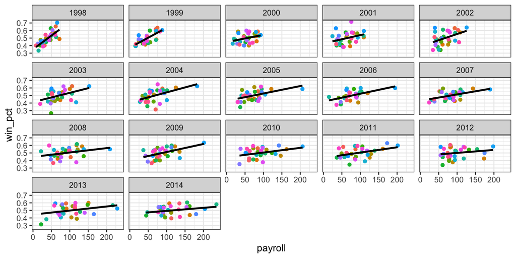

```r
mldata2 %>%
  ggplot(aes(x=payroll, y=win_pct, group = year, color=team)) +
  geom_point()+
  geom_smooth(method="lm", formula=y~x, se=F,color = "black")+
  facet_wrap(~year) +
  theme_bw() +
  theme(legend.position = 0)
```